# 02 - Waterbodies

Angus Watters

2023-05-11

Code reads in geopackage (gpkg) files located in a directory specified by the variable `wb_dir`. It then performs a series of spatial operations on each file, specifically for water body features, and outputs the resulting data to new “.gpkg” files in a specified reference directory `reference_dir`.

The loop in the code iterates through each “.gpkg” file in `wb_dir` and performs the following operations on each file:

# 1. Read in the waterbody data (`wb`)

We read in our waterbodies data. The data is made up of 1606 polygon geometries .

```r
# Step 7: Read in the water body data from the current file as an sf object
wb = read_sf(file)

wb
```

```
## Simple feature collection with 1606 features and 12 fields
## Geometry type: MULTIPOLYGON
## Dimension:     XY, XYZ
## Bounding box:  xmin: -88.61908 ymin: 34.13638 xmax: -81.5125 ymax: 37.0996
## z_range:       zmin: 0 zmax: 0
## Geodetic CRS:  NAD83
## # A tibble: 1,606 × 13
##       COMID FDATE      RESOLUTION GNIS_ID GNIS_NAME AREASQKM ELEVATION REACHCODE
##       <int> <date>     <chr>      <chr>   <chr>        <dbl>     <dbl> <chr>
##  1 19761090 1999-09-13 Medium     <NA>    <NA>         0.14          0 <NA>
##  2 22538778 1999-06-17 Medium     <NA>    <NA>         0.056         0 <NA>
##  3 22538780 1999-06-17 Medium     <NA>    <NA>         0.103         0 <NA>
##  4 22538782 1999-06-17 Medium     <NA>    <NA>         0.031         0 <NA>
##  5 22538788 1999-06-17 Medium     <NA>    <NA>         0.079         0 <NA>
##  6 22538790 1999-06-17 Medium     <NA>    <NA>         0.052         0 <NA>
##  7 22538798 1999-06-17 Medium     <NA>    <NA>         0.11          0 <NA>
##  8 22538804 1999-06-17 Medium     <NA>    <NA>         0.096         0 <NA>
##  9 22538806 1999-06-17 Medium     <NA>    <NA>         0.07          0 <NA>
## 10 22538808 1999-06-17 Medium     <NA>    <NA>         0.06          0 <NA>
## # ℹ 1,596 more rows
## # ℹ 5 more variables: FTYPE <chr>, FCODE <int>, SHAPE_LENG <dbl>,
## #   SHAPE_AREA <dbl>, geom <MULTIPOLYGON [°]>
```

```
##
##           GEOMETRY              POINT         LINESTRING            POLYGON
##                  0                  0                  0                  0
##         MULTIPOINT    MULTILINESTRING       MULTIPOLYGON GEOMETRYCOLLECTION
##                  0                  0               1606                  0
##     CIRCULARSTRING      COMPOUNDCURVE       CURVEPOLYGON         MULTICURVE
##                  0                  0                  0                  0
##       MULTISURFACE              CURVE            SURFACE  POLYHEDRALSURFACE
##                  0                  0                  0                  0
##                TIN           TRIANGLE
##                  0                  0
```

# 2. Drop, rename, and reattach geometries (`tmp`)

We want to get rid of Z/M dimensions from our features and cleanup the column names.

```r
# Drop the geometry column and rename column names to upper case
tmp = st_drop_geometry(wb)
names(tmp) <- toupper(names(tmp))

# drop Z/M dimensions and bring back original geometry
wb = st_zm(
      st_as_sf(
        cbind(tmp, st_geometry(wb))
        )
      )
```

# 3. Clean and dissolve (`clean_wbs`)

Next thing we do is, union polygons by the attribute `COMID` and transform to the coordinate reference system with EPSG 5070. We remove holes from the polygons and join with the original water body data based on the `COMID` attribute

```r
clean_wbs =
  wb %>%
  union_polygons("COMID") %>%
  st_transform(5070) %>%
  sf_remove_holes() %>%
  left_join(
    st_drop_geometry(wb),
    by = "COMID"
    ) %>%
  select(GNIS_ID, GNIS_NAME, COMID, FTYPE)

clean_wbs
```

```
## Simple feature collection with 1606 features and 4 fields
## Geometry type: GEOMETRY
## Dimension:     XY
## Bounding box:  xmin: 649682.3 ymin: 1275434 xmax: 1274453 ymax: 1640844
## Projected CRS: NAD83 / Conus Albers
## First 10 features:
##    GNIS_ID GNIS_NAME   COMID    FTYPE                       geometry
## 1     <NA>      <NA> 1861172 LakePond POLYGON ((670322.7 1588713,...
## 2     <NA>      <NA> 1861184 LakePond POLYGON ((670410.3 1586713,...
## 3     <NA>      <NA> 1861186 LakePond POLYGON ((670901.6 1586505,...
## 4     <NA>      <NA> 1861190 LakePond POLYGON ((670627.2 1585994,...
## 5     <NA>      <NA> 1861200 LakePond POLYGON ((653796.8 1583353,...
## 6     <NA>      <NA> 1861206 LakePond POLYGON ((654580.9 1582812,...
## 7     <NA>      <NA> 1861212 LakePond POLYGON ((651170.2 1582308,...
## 8     <NA>      <NA> 1861216 LakePond POLYGON ((651110.3 1582203,...
## 9     <NA>      <NA> 1861218 LakePond POLYGON ((651062.2 1581944,...
## 10    <NA>      <NA> 1861222 LakePond POLYGON ((655582.2 1582139,...
```

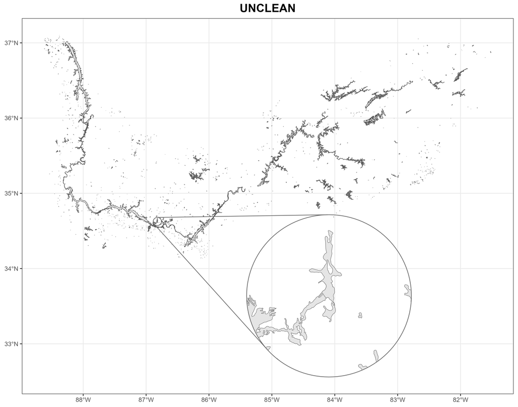

```
##
##           GEOMETRY              POINT         LINESTRING            POLYGON
##                  0                  0                  0               1604
##         MULTIPOINT    MULTILINESTRING       MULTIPOLYGON GEOMETRYCOLLECTION
##                  0                  0                  2                  0
##     CIRCULARSTRING      COMPOUNDCURVE       CURVEPOLYGON         MULTICURVE
##                  0                  0                  0                  0
##       MULTISURFACE              CURVE            SURFACE  POLYHEDRALSURFACE
##                  0                  0                  0                  0
##                TIN           TRIANGLE
##                  0                  0
```

# 4. Seperate waterbodies with missing GNIS IDs

We now want to seperate waterbodies into 2 groups– waterbodies with missing data and waterbodies without missing data.

```r
# Filter rows where GNIS_NAME is NA
missing_wb =
  clean_wbs %>%
  filter(is.na(GNIS_ID)) %>%
  mutate(member_comid = as.character(COMID))

# Filter rows where GNIS_NAME is not NA and add a new area_sqkm column
nomissing_wb =
  clean_wbs %>%
  filter(!is.na(GNIS_ID)) %>%
  mutate(area_sqkm = add_areasqkm(.))
```

If we find the number of unique COMIDs in our `nomissing_wb` dataset and compare it to the number of unique GNIS IDs, we can see that we have several GNIS IDs that are made up of multiple COMIDs.

| ID | Unique count |
| --- | --- |
| COMID | 430 |
| GNIS_ID | 425 |

# 5. Resolve multilple COMIDs per GNIS ID

If we look closely at our waterbody polygons, we’ll see that some GNIS IDs contain multiple, attached polygons.

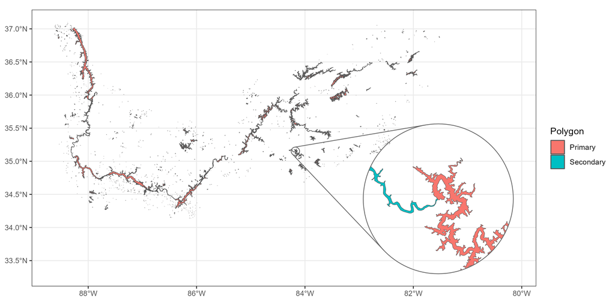

Highlighting GNIS IDs with multiple waterbody geometries (VPU 6)

Our goal here is to dissolve GNIS ID waterbodies with multiple polygons, into single polygon geometries. This is highlighted in the figure below where a GNIS ID corresponds to multiple COMIDs and polygon geometries.

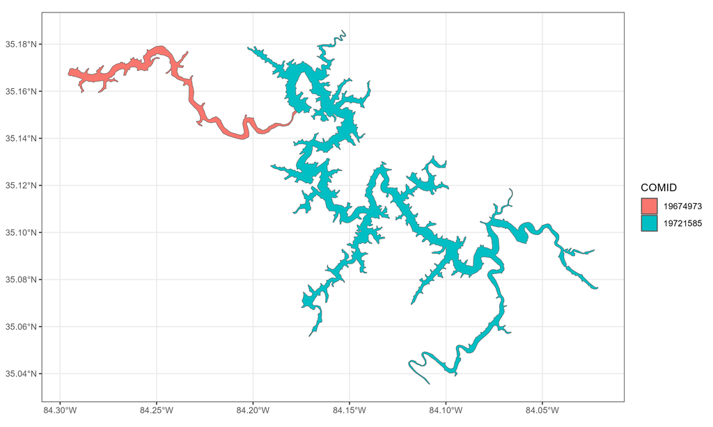

GNIS ID: 1008755 (VPU 6)

To resolve situations like this, We first dissolve these 2 polygons into a single polygon. Next we then join our unioned polygon back with our original data so that we can stash the respective COMIDs into a `member_comids` column in the unioned dataset. So instead of having 2 rows of data representing the same GNIS ID and different COMIDs/geometries, we know will have a single row of data for each GNIS ID with a single geometry and a `member_comids` row with a list of all the COMIDs in the polygon.

In this example, after we have joined out unioned shape with our original dataset, we just need to create the `member_comids` column, and just keep the column with the largest area value (this will be recalculated later on to account for the unioning process).

```r
nomissing_wb %>%
  dplyr::filter(GNIS_ID == "1008755") %>%
  hydrofab::union_polygons("GNIS_ID") %>%
  dplyr::left_join(
      sf::st_drop_geometry(
        dplyr::filter(nomissing_wb, GNIS_ID == "1008755")
        ),
      by = "GNIS_ID"
    ) %>%
    dplyr::group_by(GNIS_ID) %>%
    dplyr::mutate(
      member_comid = paste(COMID, collapse = ",")
      ) %>%
    dplyr::slice_max(area_sqkm) %>%
    dplyr::ungroup()
```

```
## Simple feature collection with 1 feature and 6 fields
## Geometry type: POLYGON
## Dimension:     XY
## Bounding box:  xmin: 1054451 ymin: 1397994 xmax: 1080350 ymax: 1414198
## Projected CRS: NAD83 / Conus Albers
## # A tibble: 1 × 7
##   GNIS_ID GNIS_NAME         COMID FTYPE    area_sqkm                    geometry
##   <chr>   <chr>             <int> <chr>        <dbl>               <POLYGON [m]>
## 1 1008755 Apalachia Lake 19721585 LakePond      25.1 ((1071195 1406260, 1071185…
## # ℹ 1 more variable: member_comid <chr>
```

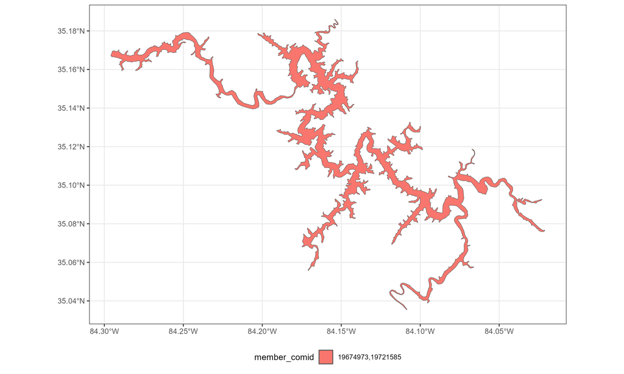

GNIS ID: 1008755 (VPU 6)

# 6. Bring everything back together

In a single step we will:

1. Union all our waterbodies with GNIS information by there GNIS IDs
2. Stash all COMIDs of unioned waterbodies into a column
3. Remove duplicate rows
4. Bind our rectified waterbodies back with the GNIS-less waterbodies
5. Recalculate area values

```r
out =
  nomissing_wb %>%
  hydrofab::union_polygons("GNIS_ID") %>%
  dplyr::left_join(
    sf::st_drop_geometry(nomissing_wb),
    by = "GNIS_ID"
    ) %>%

  dplyr::group_by(GNIS_ID) %>%
  dplyr::mutate(
    member_comid = paste(COMID, collapse = ",")
    ) %>%
  dplyr::slice_max(area_sqkm) %>%
  dplyr::ungroup() %>%
  dplyr::bind_rows(missing_wb) %>%
  dplyr::select(GNIS_ID, GNIS_NAME, COMID, FTYPE, member_comid) %>%
  dplyr::mutate(
    area_sqkm = hydrofab::add_areasqkm(.)
    )

out
```

```
## Simple feature collection with 1601 features and 6 fields
## Geometry type: GEOMETRY
## Dimension:     XY
## Bounding box:  xmin: 649682.3 ymin: 1275434 xmax: 1274453 ymax: 1640844
## Projected CRS: NAD83 / Conus Albers
## # A tibble: 1,601 × 7
##    GNIS_ID GNIS_NAME          COMID FTYPE member_comid                  geometry
##  * <chr>   <chr>              <int> <chr> <chr>                    <POLYGON [m]>
##  1 1008634 Pine Shore Lakes  2.22e7 Lake… 22163180     ((1195360 1424360, 11953…
##  2 1008755 Apalachia Lake    1.97e7 Lake… 19674973,19… ((1071195 1406260, 10711…
##  3 1008780 Lake Arrowhead    2.22e7 Lake… 22163166     ((1202218 1426690, 12022…
##  4 1008802 Lake Ashnoca      2.22e7 Lake… 22159370     ((1198582 1473773, 11985…
##  5 1008917 Banks Lake        2.22e7 Lake… 22163090     ((1203725 1443959, 12037…
##  6 1008951 Bass Pond         2.22e7 Lake… 22159386     ((1204580 1471646, 12045…
##  7 1009154 Beetree Reservoir 2.22e7 Lake… 22159350     ((1215983 1486780, 12160…
##  8 1009546 Boot Lake         2.22e7 Lake… 22163178     ((1199146 1425427, 11991…
##  9 1009858 Busbee Reservoir  2.22e7 Lake… 22159378     ((1208679 1473480, 12086…
## 10 1010118 Cedar Cliff Lake  1.97e7 Lake… 19729410     ((1160317 1434017, 11602…
## # ℹ 1,591 more rows
## # ℹ 1 more variable: area_sqkm <dbl>
```

We went from 1606 waterbody geometries to 1601 waterbody geometries. 5 COMIDs in our original dataset were dissolved with other COMIDs that share the same GNIS ID. We are then left with a single polygon geometry for every GNIS ID waterbody.

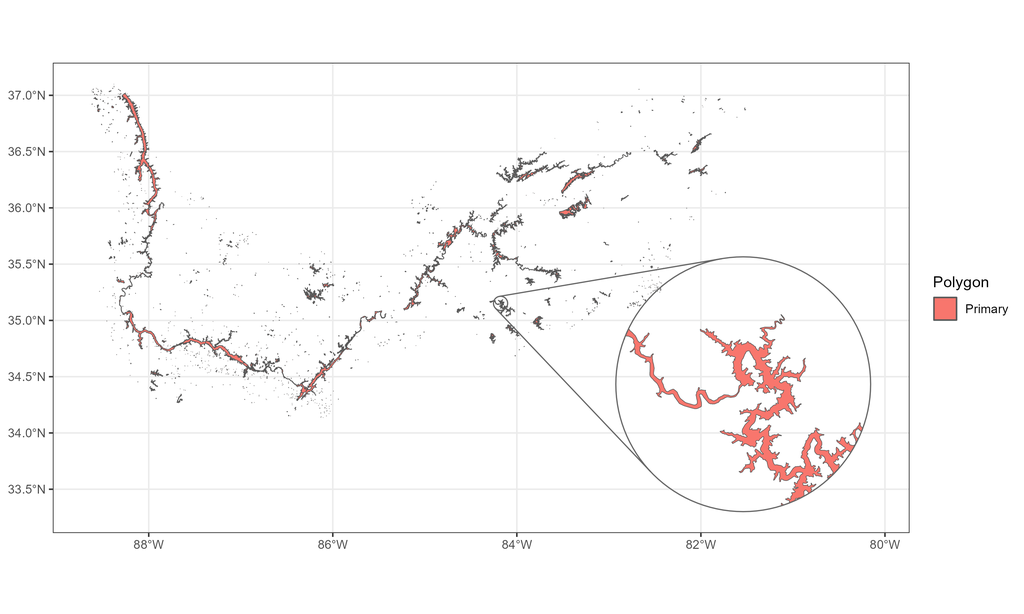

Revised NHDPlusv2 waterbodies (VPU 6)